# Assignment-1

Name:Shreya Banerjee SRN:PES1201700198

```r
#Packages required
require(data.table)
```

```r
require(plotrix)
path='/Users/shreyabanerjee/Assignment1'
```

```r
data1=fread("general_data.csv")
data2=fread("employee_survey_data.csv")
data3=fread("manager_survey_data.csv")
data1=na.omit(data1)      #omitting Na values
data2=na.omit(data2)
data3=na.omit(data3)
data4=merge(data1,data2)   #merging two files
data=merge(data4,data3)    #merging the third file
```

## Question 1)a.

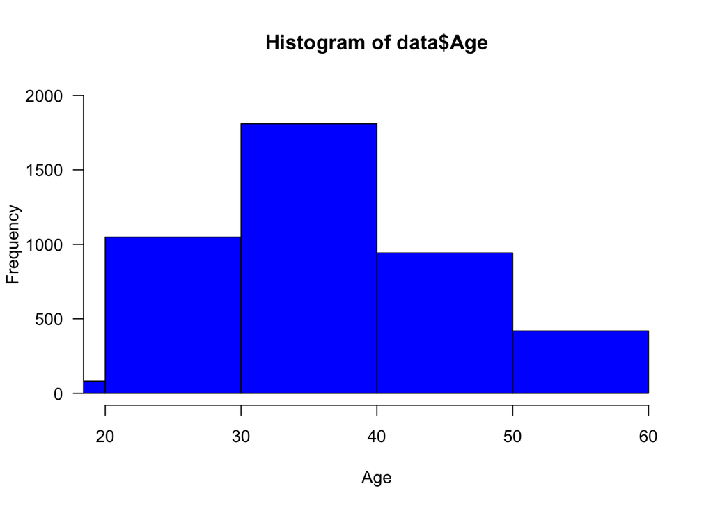

```r
hist(data$Age,xlim=c(20,60),ylim=c(0,2000),xlab="Age",breaks=5,las=1,col="blue")
```

**The graph is skewed to the right(positively skewed).**

```r
avg_incomes=c(0,0,0,0,0)
#calculating average incomes for all the age intervals beginning from 20-29
for(i in 2:5){
avg_incomes[i]=mean(data$MonthlyIncome[data$Age>=i*10 & data$Age<i*10+10])
}
print(avg_incomes)
```

```
## [1]     0.00 65044.02 65660.55 65937.94 59292.87
```

```r
print(max(avg_incomes))
```

```
## [1] 65937.94
```

**40-49 age group has the highest average monthly income.**

## Question 1)b.

```r
#sub is a table containing records(income,job and working years) of employees within the range 40-49
sub =subset(data, data$Age >= 40 & data$Age<50,select=c(MonthlyIncome,JobRole,TotalWorkingYears))
sub_sorted=sub[order(sub$MonthlyIncome)]    #sorting the incomes in increasing order
incomes=unique(sub_sorted$MonthlyIncome)    #obtaining unique values of incomes
fifth_highest=incomes[length(incomes)-4]    #all the salaries greater than the fifth highest                                                 salaries required
sub =subset(sub_sorted, sub_sorted$MonthlyIncome >=fifth_highest)  #sub contains the details of                                                            employees with 5 highest salaries
print(sub)
```

```
##     MonthlyIncome            JobRole TotalWorkingYears
##  1:        196270    Sales Executive                25
##  2:        196270    Sales Executive                25
##  3:        196270    Sales Executive                25
##  4:        197170 Research Scientist                10
##  5:        197170 Research Scientist                10
##  6:        197170 Research Scientist                10
##  7:        197400  Research Director                24
##  8:        197400  Research Director                24
##  9:        197400  Research Director                24
## 10:        199430            Manager                15
## 11:        199430            Manager                15
## 12:        199430            Manager                15
## 13:        199990 Research Scientist                17
## 14:        199990 Research Scientist                17
## 15:        199990 Research Scientist                17
```

## Question 1)c

```r
#subs is a table containing records(income and job role) of employees within the range 40-49
subs =subset(data, data$Age >= 40 & data$Age < 49,select=c(MonthlyIncome,JobRole))
a=aggregate(subs$MonthlyIncome, by=list(subs$JobRole), FUN=mean)
print(a)
```

```
##                     Group.1        x
## 1 Healthcare Representative 56731.97
## 2           Human Resources 80234.44
## 3     Laboratory Technician 67836.42
## 4                   Manager 78585.26
## 5    Manufacturing Director 68103.12
## 6         Research Director 47427.59
## 7        Research Scientist 69156.97
## 8           Sales Executive 63713.84
## 9      Sales Representative 72947.89
```

```r
#a contains the average income of each job role
avg_incomes=a$x
job_roles=a$Group.1
print(job_roles)
```

```
## [1] "Healthcare Representative" "Human Resources"
## [3] "Laboratory Technician"     "Manager"
## [5] "Manufacturing Director"    "Research Director"
## [7] "Research Scientist"        "Sales Executive"
## [9] "Sales Representative"
```

```r
print(avg_incomes)
```

```
## [1] 56731.97 80234.44 67836.42 78585.26 68103.12 47427.59 69156.97 63713.84
## [9] 72947.89
```

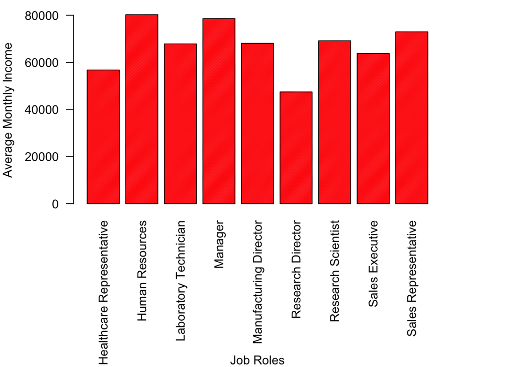

```r
par(mar=c(11,5,1,5))
barplot(avg_incomes,names.arg=job_roles,density=100,las=2,ylab="Average Monthly Income",col=c("red"),ann=FALSE)
mtext(side = 1, text = "Job Roles", line = 10)
mtext(side = 2, text = "Average Monthly Income", line = 4)
```

## Question 2)

```r
counts <- table(data$EnvironmentSatisfaction, data$MaritalStatus)
print(counts)
```

```
##
##     Divorced Married Single
##   1      182     369    279
##   2      171     416    252
##   3      291     636    392
##   4      305     548    459
```

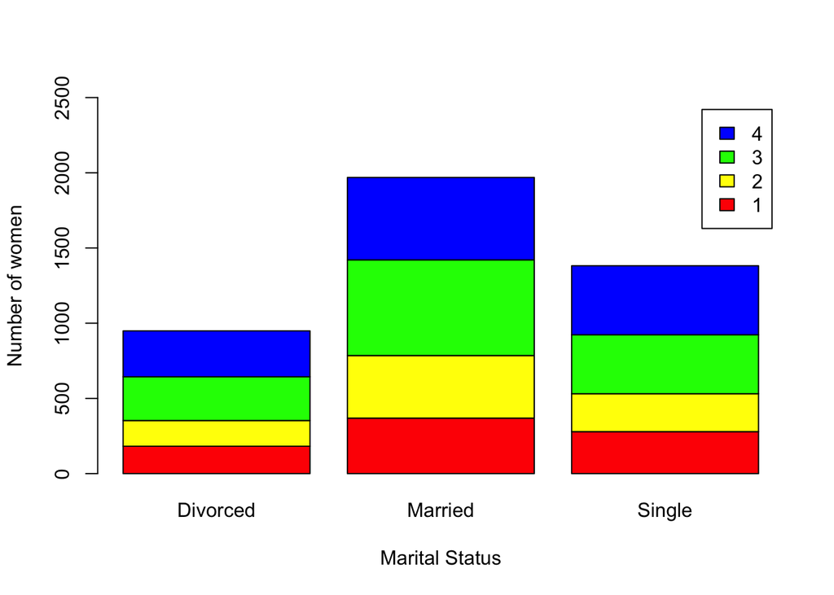

```r
barplot(counts,ylim=c(0,2500),ylab="Number of women",xlab="Marital Status",col=c("red","yellow","green","blue"),legend.text = TRUE)
```

## Question 3)

```r
tab1=data.frame(table(data$Department))   #grouping the data department-wise
dept=tab1$Var1                            #departments
in_each_dept=tab1$Freq             #number of employees in each department
print(tab1)
```

```
##                     Var1 Freq
## 1        Human Resources  186
## 2 Research & Development 2807
## 3                  Sales 1307
```

```r
a=subset(data,data$Attrition=="Yes")    #contains tuples for which attrition is yes
tab=data.frame(table(a$Department))    #number of employees with attrition in each department
print(tab)
```

```
##                     Var1 Freq
## 1        Human Resources   54
## 2 Research & Development  443
## 3                  Sales  198
```

```r
att_yes=tab$Freq                       #number of employees with attrition in each department

perc=c(0,0,0)
for (i in 1:length(in_each_dept)){
  perc[i] <- att_yes[i]*100/in_each_dept[i]     #percentage of employees with attrition in each                                                  department
  }
A=min(perc)
ind=which(perc==A)                            #finding index of department with minimum attrition
print(dept[ind])
```

```
## [1] Sales
## Levels: Human Resources Research & Development Sales
```

**Sales department has least attrition in terms of percentage of employees in that department.**

## Question 4)a

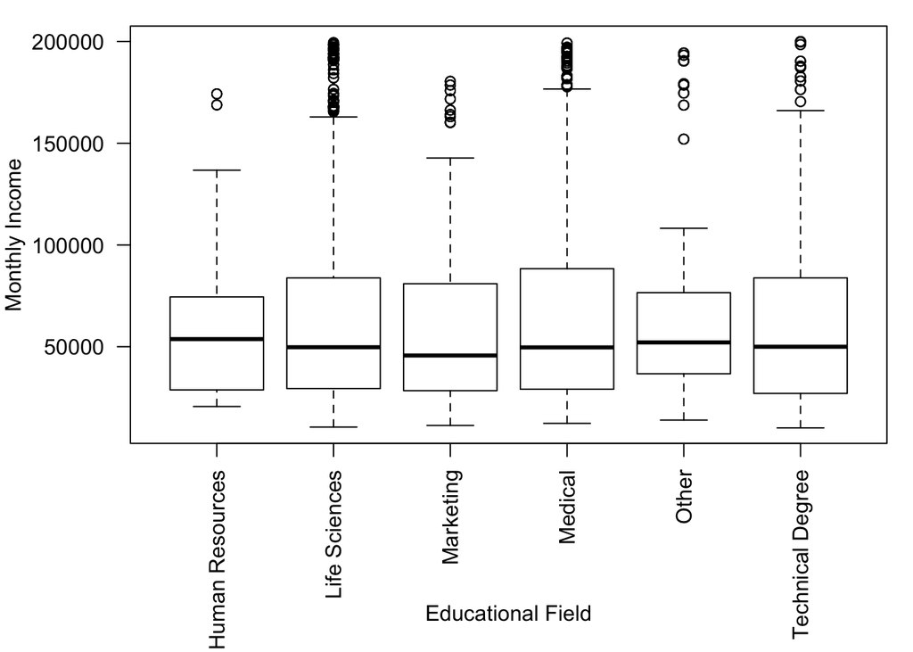

```r
par(mar=c(8,5,1,1))
boxplot(data$MonthlyIncome~data$EducationField,las=2,ann=FALSE)
mtext(side = 1, text = "Educational Field", line = 6)
mtext(side = 2, text = "Monthly Income", line = 4)
```

```r
tapply(data$MonthlyIncome, data$EducationField, summary)
```

```
## $`Human Resources`
##    Min. 1st Qu.  Median    Mean 3rd Qu.    Max.
##   20610   28750   53730   60523   74460  174260
##
## $`Life Sciences`
##    Min. 1st Qu.  Median    Mean 3rd Qu.    Max.
##   10510   29420   49735   65393   83800  199430
##
## $Marketing
##    Min. 1st Qu.  Median    Mean 3rd Qu.    Max.
##   11290   28370   45680   59303   80950  180410
##
## $Medical
##    Min. 1st Qu.  Median    Mean 3rd Qu.    Max.
##   12320   29110   49655   66973   88340  199260
##
## $Other
##    Min. 1st Qu.  Median    Mean 3rd Qu.    Max.
##   13930   36690   52100   66666   76550  194360
##
## $`Technical Degree`
##    Min. 1st Qu.  Median    Mean 3rd Qu.    Max.
##   10090   27030   49990   63718   83810  199990
```

## Question 4)b

```r
women_avg_income=mean(data$MonthlyIncome[data$Gender=="Female"])
men_avg_income=mean(data$MonthlyIncome[data$Gender=="Male"])
men_avg_income-women_avg_income
```

```
## [1] 589.5354
```

**Gender pay gap is Rs.589.5354.**

## Question 4)c

```r
aggregate(data$MonthlyIncome, by = list(data$EducationField), FUN = quantile, probs  = 0.95)
```

```
##            Group.1      x
## 1  Human Resources 168850
## 2    Life Sciences 176500
## 3        Marketing 160252
## 4          Medical 183000
## 5            Other 181468
## 6 Technical Degree 182344
```

**183000 is the 95th percentile monthly income for the Medical Education Field.**

## Question 5)

Skewness is the measure of symmetry. It is the degree of distortion from the normal distribution. A symmetrical distribution will have a skewness of 0. Positive Skewness- when the tail on the right side of the distribution is longer or fatter. Negative Skewness- when the tail of the left side of the distribution is longer or fatter than the tail on the right side.

Kurtosis is the measure of peakedness. High kurtosis in a data set is an indicator that data has heavy tails or outliers. Low kurtosis in a data set is an indicator that data has light tails or lack of outliers.